# html

## Load Data

```python
import pandas as pd
import numpy as np

CarOwners = pd.read_csv('https://storage.googleapis.com/datalynn-datasets/interview-challenge/transportation/Uber_Car_Lending/CarOwners.csv')
PotentialDrivers = pd.read_csv('https://storage.googleapis.com/datalynn-datasets/interview-challenge/transportation/Uber_Car_Lending/PotentialDrivers.csv')
```

### Question 1

Uber believes that popular car models may be more attractive to potential drivers and have a higher lending rate. Using the CarOwners dataset, determine which car models are the most popular among our registered owners.

**Problem Solving Ideas and Tips**:

- This question requires aggregating the count of car models in the CarOwners dataset.
- The result should be ordered in descending order to get the most popular models at the top.

```python
import sqlite3

# Create a connection to a local SQLite database
conn = sqlite3.connect(':memory:')

# Convert pandas dataframe to SQL table
CarOwners.to_sql('CarOwners', conn, if_exists='replace', index=False)

# SQL Solution for Question 1

query = """
SELECT CarModel, COUNT(*) as Count
FROM CarOwners
GROUP BY CarModel
ORDER BY Count DESC
"""

popular_car_models = pd.read_sql(query, conn)
popular_car_models
```

|  | CarModel | Count |
| --- | --- | --- |
| 0 | Toyota Camry | 154 |
| 1 | Hyundai Elantra | 147 |
| 2 | Honda Civic | 142 |
| 3 | Tesla Model 3 | 116 |
| 4 | Ford Focus | 102 |
| 5 | Audi A4 | 101 |
| 6 | BMW 3 Series | 98 |
| 7 | Chevrolet Malibu | 87 |
| 8 | Mercedes C Class | 53 |

### Question 2

One of the critical aspects for Uber's new venture is to understand which car owners might be willing to rent out their vehicles. Using data attributes from the CarOwners dataset like CarAge, OwnerRating, and PreviousRentals, develop a model to predict an owner's willingness. Discuss how you'd approach this problem, the kind of model you'd use, and its evaluation metrics.

**Problem Solving Ideas and Tips**:

- Start with Exploratory Data Analysis (EDA) to understand the distribution of the features and target variable.
- Treat the problem as a binary classification, where `1` denotes the owner is willing to lend the car, and `0` otherwise.
- Split the dataset into training and testing sets.
- Use a suitable algorithm for binary classification, for example, Logistic Regression, Decision Trees, Random Forest, or Gradient Boosted Trees.
- After training the model, evaluate its performance using metrics suitable for classification, such as accuracy, precision, recall, F1-score, and ROC-AUC.

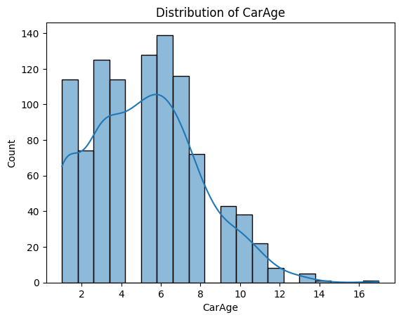

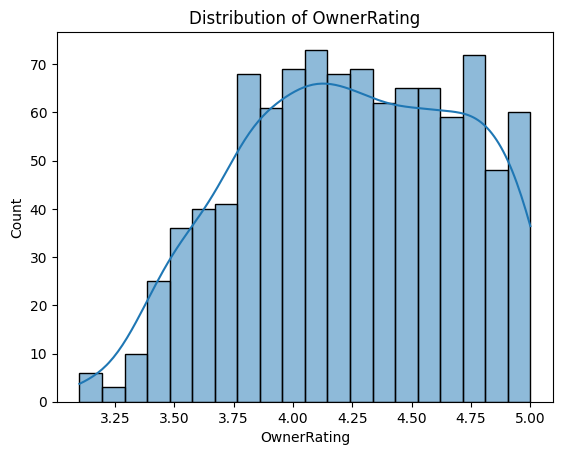

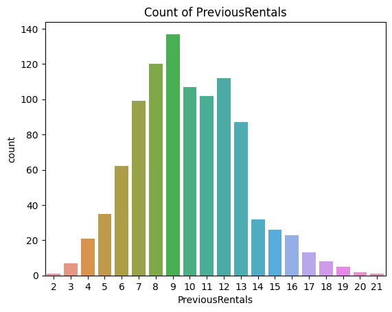

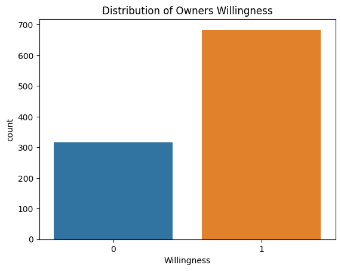

```python
## Exploratory Data Analysis (EDA)
import matplotlib.pyplot as plt
import seaborn as sns

# Distribution of CarAge
sns.histplot(CarOwners['CarAge'], kde=True)
plt.title('Distribution of CarAge')
plt.show()

# Distribution of OwnerRating
sns.histplot(CarOwners['OwnerRating'], kde=True, bins=20)
plt.title('Distribution of OwnerRating')
plt.show()

# Count of PreviousRentals
sns.countplot(data=CarOwners, x='PreviousRentals')
plt.title('Count of PreviousRentals')
plt.show()

# Distribution of target variable (Willingness)
sns.countplot(data=CarOwners, x='Willingness')
plt.title('Distribution of Owners Willingness')
plt.show()
```

```python
## Model Development and Evaluation

from sklearn.model_selection import train_test_split
from sklearn.ensemble import RandomForestClassifier
from sklearn.metrics import accuracy_score, classification_report, roc_auc_score

# Splitting data
X = CarOwners[['CarAge', 'OwnerRating', 'PreviousRentals']]
y = CarOwners['Willingness']

X_train, X_test, y_train, y_test = train_test_split(X, y, test_size=0.3, random_state=42)

# Train a Random Forest model
clf = RandomForestClassifier(n_estimators=100, random_state=42)
clf.fit(X_train, y_train)

# Predictions
y_pred = clf.predict(X_test)

# Evaluation
print("Accuracy:", accuracy_score(y_test, y_pred))
print("Classification Report:\n", classification_report(y_test, y_pred))
print("ROC-AUC Score:", roc_auc_score(y_test, y_pred))
```

```
Accuracy: 0.77
Classification Report:
               precision    recall  f1-score   support

           0       0.65      0.62      0.63        97
           1       0.82      0.84      0.83       203

    accuracy                           0.77       300
   macro avg       0.74      0.73      0.73       300
weighted avg       0.77      0.77      0.77       300

ROC-AUC Score: 0.7304606165253161
```

The RandomForestClassifier is used here due to its capability to handle non-linearity, its robustness to outliers, and its ability to capture feature interactions. The chosen evaluation metrics give a comprehensive view of the model's performance in terms of both individual class predictions and its ability to rank predictions.

For further improvement, hyperparameter tuning, feature engineering, and usage of more complex models like Gradient Boosted Trees or Neural Networks can be explored.

### Question 3

Pricing the lending service is crucial for both car owners and potential drivers. Using available data, discuss a mechanism to decide on a lending price. Consider aspects like car model popularity, owner preferences, and potential driver demand.

**Problem Solving Ideas and Tips**:

- The lending price can be influenced by both the supply (number of cars available of a particular model) and the demand (how popular a model is among potential drivers).
- While the exact price can't be determined without a 'LendingPrice' column, you can derive an importance score based on various factors.
- This score can then be used in various ways: as a reference point for bidding, as a base price with surcharges/discounts based on demand and supply, or as an input to a more sophisticated pricing algorithm.

**Solution**:

**Step 1**

**1. Deriving an Importance Score for Each Car Model**: To determine the "importance" or "value" of each car model, you can use the popularity of the model, owner rating, car age, and previous rentals.

**2. Mechanism Suggestion**:

Given the derived ImportanceScore:

- **Static Pricing**:
  - Price cars based on their `ImportanceScore`, higher the score, higher the base lending price.
  - Consider operational costs. While the importance score provides a market-driven price, don't forget to factor in operational costs (like insurance, maintenance, Uber’s commission) to ensure profitability.
- **Bidding System with Base Price**:
  - Use the `ImportanceScore` to derive a base price for each car. Allow potential drivers to bid on the cars, but use this derived price as a minimum bidding threshold.

In the absence of actual lending price information, these strategies use derived metrics and available data to inform pricing decisions.

Here's an example of deriving the importance score:

```python
# Assuming a CarOwners DataFrame
# Giving weights based on the perceived importance of each factor (these weights can be adjusted based on business insights)
weights = {
    'popularity': 0.3, # based on the number of each model
    'OwnerRating': 0.3,
    'CarAge': -0.1,  # Negative as older cars might be less valuable
    'PreviousRentals': 0.1
}

# Count the popularity of each car model
popularity = CarOwners['CarModel'].value_counts(normalize=True)
scale_factor = 1.2

# Calculate an importance score for each car
CarOwners['ImportanceScore'] = (
    popularity[CarOwners['CarModel']].values * weights['popularity'] +
    CarOwners['OwnerRating'] * weights['OwnerRating'] +
    (CarOwners['CarAge'] / CarOwners['CarAge'].max()) * weights['CarAge'] +
    CarOwners['PreviousRentals'] / CarOwners['PreviousRentals'].max() * weights['PreviousRentals']
) * scale_factor

# Display top 10 cars based on ImportanceScore
top_cars = CarOwners.sort_values(by='ImportanceScore', ascending=False).head(10)
top_cars
```

|  | OwnerID | CarModel | CarAge | PreviousRentals | AvailabilityPreference | OwnerRating | Willingness | ImportanceScore |
| --- | --- | --- | --- | --- | --- | --- | --- | --- |
| 257 | 257 | Hyundai Elantra | 3 | 17 | Weekdays | 5.0 | 1 | 1.928886 |
| 245 | 245 | Toyota Camry | 4 | 17 | Weekdays | 5.0 | 1 | 1.924348 |
| 544 | 544 | Ford Focus | 1 | 16 | Weekdays | 5.0 | 1 | 1.921090 |
| 932 | 932 | Honda Civic | 1 | 13 | Weekends | 5.0 | 1 | 1.918347 |
| 438 | 438 | Toyota Camry | 1 | 12 | Weekdays | 5.0 | 1 | 1.916953 |
| 325 | 325 | Toyota Camry | 1 | 12 | Weekdays | 5.0 | 1 | 1.916953 |
| 539 | 539 | Tesla Model 3 | 3 | 16 | Weekends | 5.0 | 1 | 1.912012 |
| 722 | 722 | Toyota Camry | 1 | 10 | Weekdays | 5.0 | 1 | 1.905524 |
| 392 | 392 | Tesla Model 3 | 1 | 12 | Anytime | 5.0 | 1 | 1.903273 |
| 952 | 952 | BMW 3 Series | 1 | 13 | Weekdays | 5.0 | 1 | 1.902507 |

**Step 2**

1. Create a PricingScale based on PotentialDrivers attributes:
- Driver Experience: Higher experience can get discounts due to less perceived risk.
- Accident History: More accidents can lead to an added premium due to higher perceived risk.
2. Based on this scale, a multiplier can be calculated for each potential driver, which can then be applied to the base price (calculated from the ImportanceScore of CarOwners) to get the final lending price for that specific driver-car combination.

Steps:

1. Creating the Pricing Scale based on Driver Attributes:
- Divide drivers into experience tiers (e.g., Newbie, Intermediate, Expert) based on driving experience years.
- Calculate a risk factor based on accident history.
2. Determining Lending Price:
- For a specific driver, use the ImportanceScore from CarOwners to get the base price of the car they're interested in.
- Apply the multiplier (based on the pricing scale) to get the final lending price.

```python
# Sample model-specific base amounts
MODEL_BASE_AMOUNTS = {
    'Toyota Camry': 55,
    'Honda Civic': 52,
    'Ford Focus': 58,
    'Chevrolet Malibu': 60,
    'BMW 3 Series': 80,
    'Tesla Model 3': 85,
    'Audi A4': 88,
    'Mercedes C Class': 92,
    'Hyundai Elantra': 56
}

# Dividing drivers into experience tiers
bins = [0, 5, 15, np.inf]
labels = ['Newbie', 'Intermediate', 'Expert']
PotentialDrivers['ExperienceTier'] = pd.cut(PotentialDrivers['DrivingExperience'], bins=bins, labels=labels, right=False)

# Calculating risk factor based on accident history
PotentialDrivers['RiskFactor'] = PotentialDrivers['AccidentHistory'].apply(lambda x: 1.2 if x > 2 else (1.1 if x > 0 else 1.0))

# Creating the pricing scale
pricing_scale = {
    'Newbie': 1.1,
    'Intermediate': 1,
    'Expert': 0.95
}

PotentialDrivers['PriceMultiplier'] = PotentialDrivers['ExperienceTier'].map(pricing_scale).astype(float) * PotentialDrivers['RiskFactor']

# Step 2: Determining Lending Price

def get_lending_price(driver_id, car_model):
    base_amount_for_model = MODEL_BASE_AMOUNTS.get(car_model, 100)  # Default to 100 if model not in dictionary
    base_price = CarOwners[CarOwners['CarModel'] == car_model]['ImportanceScore'].iloc[0] * base_amount_for_model  # Convert importance score to a base price value
    multiplier = PotentialDrivers[PotentialDrivers['DriverID'] == driver_id]['PriceMultiplier'].iloc[0]

    return base_price * multiplier

# Example: Get lending price for driver with ID 10 interested in 'Toyota Camry'
price = get_lending_price(10, 'Toyota Camry')
print(f"The lending price for driver with ID 10 interested in 'Toyota Camry' is: {price:.2f}")
```

```
The lending price for driver with ID 10 interested in 'Toyota Camry' is: 83.43
```

### Question 4

Before launching this new service, it's essential to gauge its viability and potential risks. Discuss how you would assess the potential success of this initiative using the available data. Consider potential risks and how to do A/B test.

**Problem Solving Ideas and Tips**:

1. **Historical Data Analysis**: Check if Uber has any historical data on similar services or pilot programs. Analyzing past failures or successes can give insights.
2. **Market Research**: Before launching any service, it's essential to understand the demand. Market surveys can gauge potential interest.
3. **Risks Assessment**: Enumerate potential risks from various angles: financial, reputational, operational, and legal.
4. **Simulations**: Use the data to simulate the service's performance in different scenarios.
5. **Alternative to A/B Testing**: Given that conventional A/B testing isn't ideal, consider phased roll-outs or pilot programs in limited regions.

**Solution**:

1. **Historical Data Analysis**:
   - Use data from any similar services Uber might have offered in the past. For instance, check the success rate of car-sharing services or driver incentives.
   - Look at metrics like user adoption rate, frequency of service usage, and customer feedback.
2. **Market Research**:
   - Conduct surveys among the current user base to gauge interest in such a service. For instance, ask car owners if they'd be willing to rent out their vehicles and under what conditions.
   - Analyze data from other players in the car rental space for trends and customer preferences.
3. **Risks Assessment**:
   - **Financial Risk**: If the car gets damaged, who bears the repair cost? Consider insurance implications.
   - **Reputational Risk**: Bad experiences (like renting a malfunctioning car) can harm Uber's brand. Ensure thorough quality checks.
   - **Operational Risk**: Ensure a smooth logistics chain for handing over vehicles to drivers and returning them to owners.
   - **Legal Risk**: Different regions have varied regulations around car rentals. It's vital to ensure compliance.
4. **Simulations**:
   - Use the CarOwners and PotentialDrivers datasets to simulate how often cars might be rented out, potential earnings, and associated costs. This can give a projected ROI for the service.
5. **Alternative to A/B Testing**:
   - **Pilot Program**: Launch the service in a limited region. This tests the waters without a full commitment.
   - **Phased Roll-out**: Begin with a soft launch, introducing the service to a select group of users, and then gradually expand based on feedback and performance metrics.
   - **Feedback Mechanism**: Ensure there's a robust mechanism for users (both drivers and car owners) to provide feedback during the pilot or initial phase.

In conclusion, while the idea of renting out unused cars has potential, it's essential to approach it systematically. Data-driven insights, combined with market research and risk assessment, can guide the successful launch of this service.